# Sea surface temp and known locations

Bindoff, A., Foo, D.

12 December 2017

```r
# recommended install.packages("raster", repos = "https://cran.csiro.au") for latest version of `raster` package
# devtools::install_github("SWotherspoon/BAStag")

library(SGAT)
library(BAStag)
library(raster)
library(readr)
library(TwilightFree)
library(maptools)
```

For marine animals who traverse large distances across the latitudes, sea surface temperature (SST) data which are collected by most GLS tags can be used to improve location estimates. `TwilightFree` is able to use this information, but there are some common issues that users face which we aim to address in this tutorial.

This tutorial also demonstrates one of two methods for incorporating data about fixes at known locations, either from physical sightings, or known beaching, burrowing, or nesting locations and dates. These are sometimes evident from patterns in the light data, and can be confirmed by position estimates from an initial run that go close to the beach, burrow, or nest.

If you have *not* forked this repository from github, please download the SST data at https://github.com/ABindoff/TwilightFree/blob/master/tutorials/sst_2014_2017.RData (forking the repository avoids this step). This `rasterStack` covers mean weekly SST for the the years 2014-2017 and was obtained [from NOAA](https://www.esrl.noaa.gov/psd/repository/entry/show?entryid=12159560-ab82-48a1-b3e4-88ace20475cd). If you require data that is older or newer, download the file from NOAA and use `sst <- stack("C:/Reynolds/sst.wkmean.1990-present.nc",varname="sst",quick=TRUE)` to load it as a `raster::rasterStack` object.

```r
load("../tutorials/sst_2014_2017.RData") ## `sst`  download from https://github.com/ABindoff/TwilightFree/blob/master/tutorials/sst_2014_2017.RData
```

#### Define the extent of the grid

We know that this animal (a New Zealand fur seal) was tagged at Kangaroo Island, South Australia, and hasn’t ranged far. `makeGrid` takes lon and lat extents, a cell size (in degrees), and optionally an argument to define a land/sea mask. `pacific = T` tells `makeGrid` that we wish to use Pacific-centered coordinates.

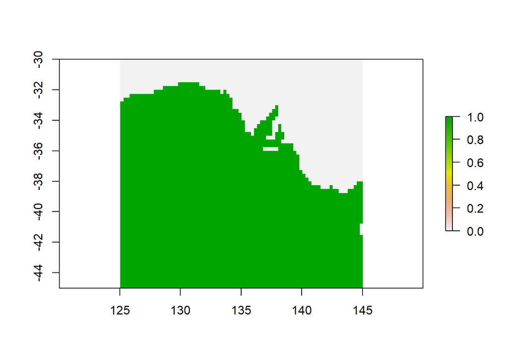

```r
grid <- makeGrid(c(125, 145), c(-45,-30), cell.size = 1/4, pacific = T)
plot(grid)
```

#### Load light and SST data

Light and SST data are typically stored in separate files (to save storage space on the tag) and need to be merged. *(The `BAStag` package offers tools that make this easy for BAS tags).*

```r
# light and temp data are often in separate files
d.lig <- read.csv("https://raw.githubusercontent.com/ABindoff/TwilightFree/master/tutorials/nzfs.lig.csv")
head(d.lig)
```

```
##               Date  Light
## 1 23/01/2017 23:43 21.576
## 2 23/01/2017 23:48 20.440
## 3 23/01/2017 23:53  6.813
## 4 23/01/2017 23:58  7.949
## 5  24/01/2017 0:03 46.558
## 6  24/01/2017 0:08 13.627
```

Note the format of the Date column. This needs to be converted to POSIXct.

```r
# fix Date to %Y-%m-%d %H:%M:%S format
d.lig$Date <- as.POSIXct(strptime(as.character(d.lig$Date), "%d/%m/%Y %H:%M", tz="GMT"))

# read temp data
d.tem <- read.csv("https://raw.githubusercontent.com/ABindoff/TwilightFree/master/tutorials/nzfs.tem.csv")
d.tem$Date <- as.POSIXct(strptime(as.character(d.tem$Date), "%d/%m/%Y %H:%M", tz="GMT"))

# align temp observations with light observations
d.lig$Temp[d.lig$Date %in% d.tem$Date] <- d.tem$Temp[d.tem$Date %in% d.lig$Date]

# check the aligned data and view image
d.lig[c(3456:3460,3500:3504),]
```

```
##                     Date    Light Temp
## 3456 2017-02-04 23:38:00 13954.84 19.1
## 3457 2017-02-04 23:43:00 12792.03   NA
## 3458 2017-02-04 23:48:00 41862.24   NA
## 3459 2017-02-04 23:53:00 41862.24   NA
## 3460 2017-02-04 23:58:00 46513.47   NA
## 3500 2017-02-05 03:18:00 30234.15   NA
## 3501 2017-02-05 03:23:00 34885.39   NA
## 3502 2017-02-05 03:28:00 34885.39   NA
## 3503 2017-02-05 03:33:00 32559.77   NA
## 3504 2017-02-05 03:38:00 17443.26 19.4
```

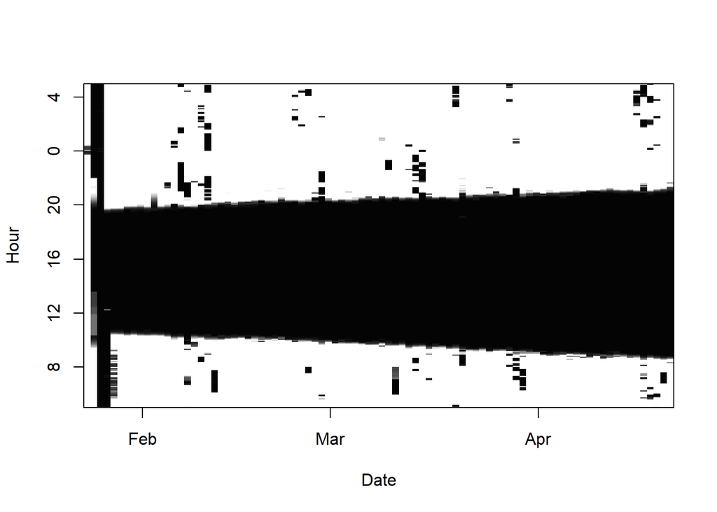

```r
lightImage(d.lig, offset = 5, zlim = c(0, 64))
```

Note the noise at the beginning of the light data, this is possibly because the tag was switched on and left in a tent or bag prior to deployment. We need to trim appropriately.

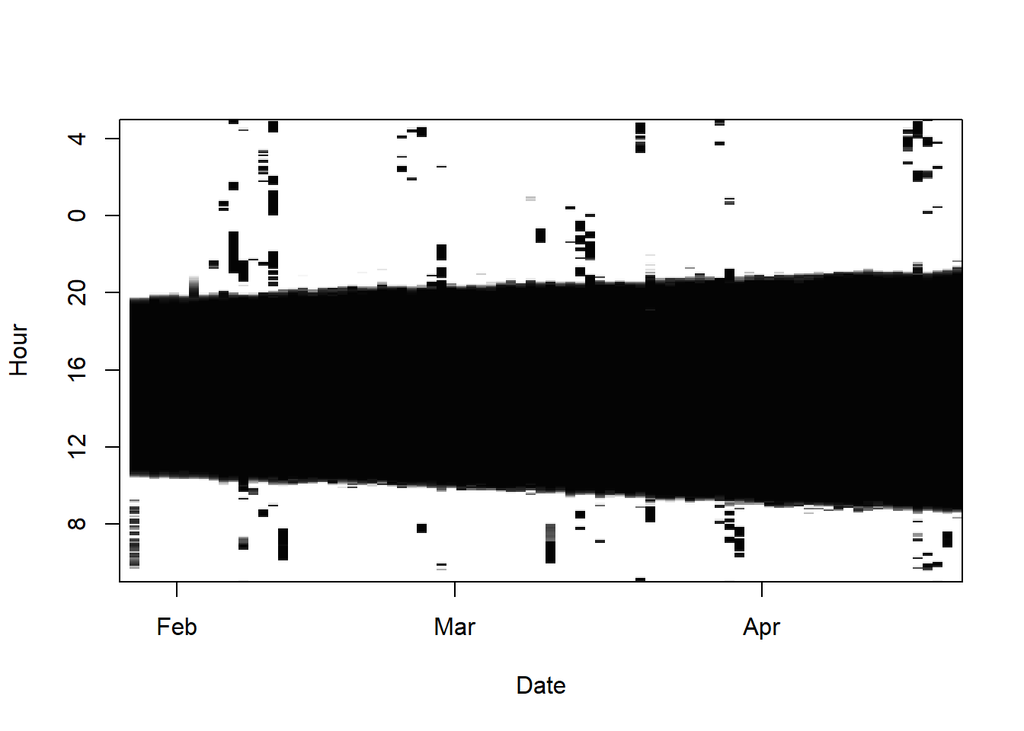

```r
# chop the calibration and transit periods off the ends
d.lig <- subset(d.lig,Date >= as.POSIXct("2017-01-27 00:00",tz = "GMT") &
                  Date < as.POSIXct("2017-04-21 00:00",tz = "GMT"))
lightImage(d.lig, offset = 5, zlim = c(0,64))
```

#### Threshold and solar zenith angle

Use `calibrate` to determine the threshold and solar zenith angle used in the model.

```r
# find optimal threshold and solar zenith angles for tag using `calibrate`
zen <- 96
day <- as.POSIXct("2017-01-28 00:00", "GMT")
thresh <- calibrate(d.lig, day, 137.22, -35.78, zen) *1.01
```

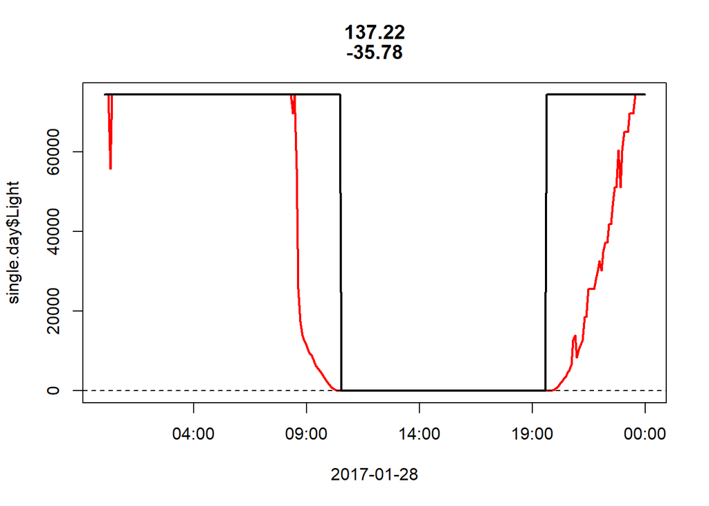

```
## [1] "max light in night window: 12.491 assuming a solar zenith angle of: 96"
```

#### Fixes

We have a small list of dates where the animal returned to the colony. This includes the deployment and retrieval dates. Normally this might be a .csv or .txt file, we just need `Date`, `Lon`, and `Lat` columns in a data frame. We pass these to the `fixd` argument in `TwilightFree`. We also pass `sst`, `zenith`, `threshold`, and the hyperparameters relating to sensor obscuration (`alpha`) and movement (`beta`). We may not specify `deployed.at` or `retrieved.at` parameters if we supply `fixd`.

```r
# dates where animal returned to the colony were recorded in field notes
# and recorded in this spreadsheet (but the Date column needs formatting)
sightings <- data.frame(Date = c("2017-01-28", "2017-02-11", "2017-02-28", "2017-03-15", "2017-03-20", "2017-04-19"),
                        Lon = 137.5,
                        Lat = -36.1)

model <- TwilightFree(d.lig,
                      alpha=c(1, 1/5),
                      beta=c(1, 1/4),
                      zenith = zen, threshold = thresh,
                      fixd = sightings, # these are the colony locations and dates
                      sst = sst) # this is the sst raster stack
```

Pass the `TwilightFree` model object to `SGAT::essie` which calculates the posterior with a forward-backward algorithm.

```r
# fit the model using the grid from `makeGrid`
fit <- SGAT::essie(model,grid,epsilon1=1.0E-4, epsilon2 = 1E-4)
```

`trip()` will return the locations from the fitted `essie` object, it’s a good idea to save these to a file. `TwilightFree` offers a basic plotting function `drawTracks` which will plot the track, and optionally another track (say, from a GPS tag). See `? drawTracks` for documentation.

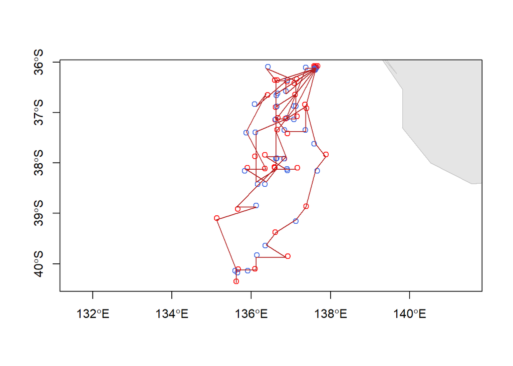

```r
# plot the result
locs <- trip(fit)
drawTracks(locs, pacific = T)
```

An optional step is to smooth the track using a state-space model such as `bsam`. You will need to install `jags` (on your computer, not in R) in order to use `bsam`, so this chunk is not evaluated by default (set `eval = T` and install jags and `bsam` to knit it).

The “trick” is to tell `bsam` that the GLS locations estimated using `TwilightFree` method are Argos locations that need smoothing.

```r
# smooth using a state space model
#install.packages("bsam")
library(bsam)
locs$Argos_loc_class <- "G"  ## set all to class "G" (trick bsam into thinking it's Argos data)
locs$lonerr <- 1 ##error in deg
locs$laterr <- 1
locs$gmt <- as.POSIXct(paste(as.character(locs$Date), "12:00:00", sep=" "), tz="GMT")
locs$ref <- 1

d <- locs[, c("ref", "gmt", "Argos_loc_class","Lon", "Lat", "lonerr", "laterr")]
colnames(d) <- c("id", "date","lc",  "lon", "lat" , "lonerr", "laterr")


fit <- fit_ssm(d, model = "DCRW", tstep = 1, adapt = 5000, samples = 5000,
               thin = 5, span = 0.2)

# diag_ssm(fit)
# plot_fit(fit)
result <- get_summary(fit)
result$Lon <- result$lon
result$Lat <- result$lat
drawTracks(result, pacific = T)
```